## CM3015 Machine Learning and Neural Networks - Coursework 2 report by EX0829

# Introduction

Here we are attempting to predict the median price of houeses in a given Boston suburb in the mid-1970s, given data points about the suburb at the time, such as the crime rate, the local property tax rate, and so on, The Boston Housing Dataset is a popular dataset in machine learning and statistics for regression analysis. It is commonly used as a benchmark dataset to evaluate and compare the performance of different regression algorithms. Here are a few reasons why the Boston Housing Dataset is so widely used:

1. Real-world relevance: The dataset contains information about house prices in the Boston area in the 1970s. It includes features such as crime rate, air pollution, number of rooms, and distance to employment centers, which are all factors that could potentially impact the price of a house. This makes the dataset relevant to real-world problems in the field of real estate.
2. Easy to understand: The dataset is relatively small, with only 506 samples, and the features are all numeric and well-defined. This makes it easy to understand and work with, even for people who are new to machine learning and regression analysis.
3. Availability: The dataset is freely available and has been used in numerous research studies and machine learning competitions, which means that there are many resources available for learning and applying regression algorithms to this dataset.
4. Reproducibility: Because the dataset has been used so widely, it is easy to compare the performance of different regression algorithms on this dataset and reproduce the results reported in other studie

## Defining the problem

We are going to use this dataset to do prediction and analization. we are going to explore the correlation of house pring with other factors such as MEDV(the median value of owner occupied homes),etc. According to the dataset, we can achieve the comparement by using linear regression and we may find out how is the house pricing in boston looks like in mid-1970s.

### Data Quality

The dataset used may not cover all the house pricing in boston, which means it may have some missing value. But still, it is good enough and very classical for learning use.

### Data Quantity

This dataset has 506 data points, split between 404 traing samples and 102 test samles.And each feature in the input data has a different scale

## Boston House Pricing Dataset

### import the data

```python
from keras.datasets import boston_housing

(train_data,train_targets),(test_data,test_targets)= boston_housing.load_data()
```

```python
train_data.shape
```

```
(404, 13)
```

```python
test_data.shape
```

```
(102, 13)
```

```python
train_targets
```

```
array([15.2, 42.3, 50. , 21.1, 17.7, 18.5, 11.3, 15.6, 15.6, 14.4, 12.1,
       17.9, 23.1, 19.9, 15.7,  8.8, 50. , 22.5, 24.1, 27.5, 10.9, 30.8,
       32.9, 24. , 18.5, 13.3, 22.9, 34.7, 16.6, 17.5, 22.3, 16.1, 14.9,
       23.1, 34.9, 25. , 13.9, 13.1, 20.4, 20. , 15.2, 24.7, 22.2, 16.7,
       12.7, 15.6, 18.4, 21. , 30.1, 15.1, 18.7,  9.6, 31.5, 24.8, 19.1,
       22. , 14.5, 11. , 32. , 29.4, 20.3, 24.4, 14.6, 19.5, 14.1, 14.3,
       15.6, 10.5,  6.3, 19.3, 19.3, 13.4, 36.4, 17.8, 13.5, 16.5,  8.3,
       14.3, 16. , 13.4, 28.6, 43.5, 20.2, 22. , 23. , 20.7, 12.5, 48.5,
       14.6, 13.4, 23.7, 50. , 21.7, 39.8, 38.7, 22.2, 34.9, 22.5, 31.1,
       28.7, 46. , 41.7, 21. , 26.6, 15. , 24.4, 13.3, 21.2, 11.7, 21.7,
       19.4, 50. , 22.8, 19.7, 24.7, 36.2, 14.2, 18.9, 18.3, 20.6, 24.6,
       18.2,  8.7, 44. , 10.4, 13.2, 21.2, 37. , 30.7, 22.9, 20. , 19.3,
       31.7, 32. , 23.1, 18.8, 10.9, 50. , 19.6,  5. , 14.4, 19.8, 13.8,
       19.6, 23.9, 24.5, 25. , 19.9, 17.2, 24.6, 13.5, 26.6, 21.4, 11.9,
       22.6, 19.6,  8.5, 23.7, 23.1, 22.4, 20.5, 23.6, 18.4, 35.2, 23.1,
       27.9, 20.6, 23.7, 28. , 13.6, 27.1, 23.6, 20.6, 18.2, 21.7, 17.1,
        8.4, 25.3, 13.8, 22.2, 18.4, 20.7, 31.6, 30.5, 20.3,  8.8, 19.2,
       19.4, 23.1, 23. , 14.8, 48.8, 22.6, 33.4, 21.1, 13.6, 32.2, 13.1,
       23.4, 18.9, 23.9, 11.8, 23.3, 22.8, 19.6, 16.7, 13.4, 22.2, 20.4,
       21.8, 26.4, 14.9, 24.1, 23.8, 12.3, 29.1, 21. , 19.5, 23.3, 23.8,
       17.8, 11.5, 21.7, 19.9, 25. , 33.4, 28.5, 21.4, 24.3, 27.5, 33.1,
       16.2, 23.3, 48.3, 22.9, 22.8, 13.1, 12.7, 22.6, 15. , 15.3, 10.5,
       24. , 18.5, 21.7, 19.5, 33.2, 23.2,  5. , 19.1, 12.7, 22.3, 10.2,
       13.9, 16.3, 17. , 20.1, 29.9, 17.2, 37.3, 45.4, 17.8, 23.2, 29. ,
       22. , 18. , 17.4, 34.6, 20.1, 25. , 15.6, 24.8, 28.2, 21.2, 21.4,
       23.8, 31. , 26.2, 17.4, 37.9, 17.5, 20. ,  8.3, 23.9,  8.4, 13.8,
        7.2, 11.7, 17.1, 21.6, 50. , 16.1, 20.4, 20.6, 21.4, 20.6, 36.5,
        8.5, 24.8, 10.8, 21.9, 17.3, 18.9, 36.2, 14.9, 18.2, 33.3, 21.8,
       19.7, 31.6, 24.8, 19.4, 22.8,  7.5, 44.8, 16.8, 18.7, 50. , 50. ,
       19.5, 20.1, 50. , 17.2, 20.8, 19.3, 41.3, 20.4, 20.5, 13.8, 16.5,
       23.9, 20.6, 31.5, 23.3, 16.8, 14. , 33.8, 36.1, 12.8, 18.3, 18.7,
       19.1, 29. , 30.1, 50. , 50. , 22. , 11.9, 37.6, 50. , 22.7, 20.8,
       23.5, 27.9, 50. , 19.3, 23.9, 22.6, 15.2, 21.7, 19.2, 43.8, 20.3,
       33.2, 19.9, 22.5, 32.7, 22. , 17.1, 19. , 15. , 16.1, 25.1, 23.7,
       28.7, 37.2, 22.6, 16.4, 25. , 29.8, 22.1, 17.4, 18.1, 30.3, 17.5,
       24.7, 12.6, 26.5, 28.7, 13.3, 10.4, 24.4, 23. , 20. , 17.8,  7. ,
       11.8, 24.4, 13.8, 19.4, 25.2, 19.4, 19.4, 29.1])
```

## Preparing the data

### All these codes below (incliding few cells after) are all refered to the DLWP book

```python
mean = train_data.mean(axis=0)
train_data -= mean
std = train_data.std(axis=0)
train_data /= std

test_data -= mean
test_data /=std

train_features = (train_data - mean )/ std
```

### Model definition

```python
from keras import models
from keras import layers

def build_model():
    model = models.Sequential()
    model.add(layers.Dense(64,activation='relu',
                            input_shape=(train_data.shape[1],)))
    model.add(layers.Dense(64, activation='relu'))
    model.add(layers.Dense(1))
    model.compile(optimizer='rmsprop',loss='mse',metrics=['mae'])
    return model
```

### K-fold validation

One way to assess a neural network's performance while tuning its parameters is to partition the available data into a training set and a validation set. However, it should be noted that the validation scores can be highly variable depending on the specific data points selected for each set, potentially leading to unreliable evaluations.

In this approach, called K-fold cross-validation, the dataset is divided into K partitions, typically with K=4. K identical models are instantiated, and each one is trained on K-1 partitions while being evaluated on the remaining partition. The validation score for the model used is then the average of the K validation scores obtained. This method provides a more reliable estimate of the model's performance than a single validation set, as it allows for the use of all data points for training and validation. It also reduces the variance of the performance estimate, as each data point is used for validation exactly once.

```python
import numpy as np

k=4
num_val_samples = len(train_data) //k
num_epochs = 100
all_scores = []
for i in range (k):
    print('processing fold #',i)
    ## Prepares the validation data: data from partition #k
    val_data = train_data[i * num_val_samples:(i+1) * num_val_samples]
    val_targets = train_targets[i * num_val_samples:(i+1) * num_val_samples]

    ## Prepares the training data: data from all other partitions
    partial_train_data = np.concatenate(
        [train_data[:i * num_val_samples],
         train_data[(i + 1) * num_val_samples:]],
        axis=0)
    partial_train_targets = np.concatenate(
        [train_targets[:i * num_val_samples],
         train_targets[(i + 1) * num_val_samples:]],
        axis=0)

    ## Builds the Keras model(already compiled)
    model = build_model()
    ## Trains the model(in silent mode, verbose = 0)
    model.fit(partial_train_data,partial_train_targets,
              epochs=num_epochs, batch_size=1, verbose=0)
    ## Evaluates the model on the validation data
    val_mse, val_mae = model.evaluate(val_data,val_targets,verbose=0)
    all_scores.append(val_mae)
```

```
processing fold # 0
processing fold # 1
processing fold # 2
processing fold # 3
```

```python
print(all_scores)
```

```
[2.1524832248687744, 2.7576234340667725, 2.554276466369629, 2.5345256328582764]
```

```python
np.mean(all_scores)
```

```
2.499727189540863
```

### Saving the validatioin logs at each fold

```python
num_epochs = 500
all_mae_histories= []

for i in range(k):
    print('processing fold #',i)
    ## Prepares the validation data:data from partition #k
    val_data = train_data[i * num_val_samples:(i + 1) * num_val_samples]
    val_targets = train_targets[i * num_val_samples:(i + 1) * num_val_samples]

    ## Prepares the training data: data from all other partitions
    partial_train_data = np.concatenate(
        [train_data[:i * num_val_samples],
         train_data[(i + 1) * num_val_samples:]],
        axis=0)
    partial_train_targets = np.concatenate(
        [train_targets[:i * num_val_samples],
         train_targets[(i + 1) * num_val_samples:]],
        axis=0)

    ## Builds the Keras model(already compiled)
    model = build_model()

    ## Compiles the model with 'mae' metric
    ## Here I added this original code so that metric will included in the model compilation, which means that it will be recorded during training.
    model.compile(optimizer='rmsprop', loss='mse', metrics=['mae'])

    ## Trains the model(in silent mode,verbose=0)
    history = model.fit(partial_train_data,partial_train_targets,
                        validation_data =(val_data,val_targets),
                        epochs=num_epochs, batch_size=1, verbose=0)

    ## Records the validation mean absolute error for each epoch
    mae_history = history.history['val_mae']
    all_mae_histories.append(mae_history)
```

```
processing fold # 0
processing fold # 1
processing fold # 2
processing fold # 3
```

### Building the history of successive mean K-folr validation scores

```python
average_mae_history = [np.mean([x[i] for x in all_mae_histories]) for i in range(num_epochs)]
```

### Plotting validation scores

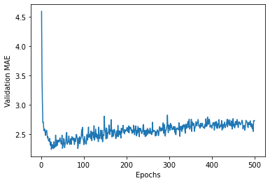

```python
import matplotlib.pyplot as plt

plt.plot(range(1,len(average_mae_history) + 1), average_mae_history)
plt.xlabel('Epochs')
plt.ylabel('Validation MAE')
plt.show()
```

### Plotting validation scores,excluding the first 10 data points

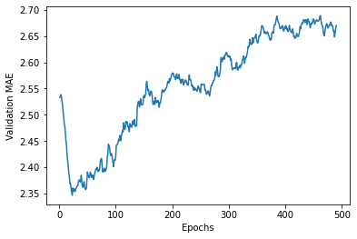

```python
def smooth_curve(points,factor = 0.9):
    smoothed_points = []
    for point in points:
        if smoothed_points:
            previous = smoothed_points[-1]
            smoothed_points.append(previous * factor + point * (1 - factor))
        else:
            smoothed_points.append(point)
    return smoothed_points

smooth_mae_history = smooth_curve(average_mae_history[10:])

plt.plot(range(1,len(smooth_mae_history) + 1),smooth_mae_history)
plt.xlabel('Epochs')
plt.ylabel('Validation MAE')
plt.show()
```

## Training the final model

```python
model = build_model()
## gets a fresh,compiled model
model.fit(train_data,train_targets,epochs =80,batch_size = 16 ,verbose = 0)
## Trains it on the entirety of the data
test_mse_score,test_mae_score = model.evaluate(test_data,test_targets)
```

```python
## result
test_mae_score
```

```
2.6324713230133057
```

Test MAE (Mean Absolute Error) score represents the average absolute difference between the actual and predicted values on a test set that the model has not seen before. It is a measure of how well the model generalizes to new data. A lower MAE indicates better performance of the model in predicting the target values.

### codes all above are all referenced from book [1] mentioned in Reference part

## Linear Regression

Training the model

Now here we are going to apply Linear Regression for analysing the data and do prediction on the house price

```python
import pandas as pd

X_train=train_data
y_train = train_targets
X_test = test_data
y_test = test_targets
# Import library for Linear Regression
from sklearn.linear_model import LinearRegression

# Create a Linear regressor
lm = LinearRegression()

# Train the model using the training sets
lm.fit(X_train, y_train)
```

```
LinearRegression()
```

```python
# Value of y intercept
lm.intercept_
```

```
22.395049504950492
```

```python
import pandas as pd
import numpy as np
from sklearn.model_selection import train_test_split
from sklearn.linear_model import LinearRegression
from sklearn.metrics import mean_squared_error, r2_score

# Load the Boston Housing dataset
from sklearn.datasets import load_boston
boston_dataset = load_boston()

# Create a pandas DataFrame from the dataset
boston = pd.DataFrame(boston_dataset.data, columns=boston_dataset.feature_names)
boston['MEDV'] = boston_dataset.target
```

[output not shown]

```python
# Select the features to use in the model
X = boston[['LSTAT', 'RM']]
Y = boston['MEDV']

# Split the data into training and test sets:
X_train, X_test, Y_train, Y_test = train_test_split(X, Y, test_size=0.2, random_state=0)

# Initialize the linear regression model:
lin_model = LinearRegression()

# Fit the model to the training data:
lin_model.fit(X_train, Y_train)
```

```
LinearRegression()
```

```python
# Evaluate the model on the training data:
y_train_predict = lin_model.predict(X_train)
rmse_train = np.sqrt(mean_squared_error(Y_train, y_train_predict))
r2_train = r2_score(Y_train, y_train_predict)

print("The model performance for the training set")
print("--------------------------------------")
print('RMSE is {}'.format(rmse_train))
print('R2 score is {}'.format(r2_train))
print("\n")

# Evaluate the model on the test data:
y_test_predict = lin_model.predict(X_test)
rmse_test = np.sqrt(mean_squared_error(Y_test, y_test_predict))
r2_test = r2_score(Y_test, y_test_predict)

print("The model performance for the testing set")
print("--------------------------------------")
print('RMSE is {}'.format(rmse_test))
print('R2 score is {}'.format(r2_test))
# Evaluate the model on the training data:
y_train_predict = lin_model.predict(X_train)
rmse_train = np.sqrt(mean_squared_error(Y_train, y_train_predict))
r2_train = r2_score(Y_train, y_train_predict)

print("The model performance for the training set")
print("--------------------------------------")
print('RMSE is {}'.format(rmse_train))
print('R2 score is {}'.format(r2_train))
print("\n")

# Evaluate the model on the test data:
y_test_predict = lin_model.predict(X_test)
rmse_test = np.sqrt(mean_squared_error(Y_test, y_test_predict))
r2_test = r2_score(Y_test, y_test_predict)

print("The model performance for the testing set")
print("--------------------------------------")
print('RMSE is {}'.format(rmse_test))
print('R2 score is {}'.format(r2_test))
```

```
The model performance for the training set
--------------------------------------
RMSE is 5.365657134224422
R2 score is 0.6618625964841894


The model performance for the testing set
--------------------------------------
RMSE is 6.114172522817781
R2 score is 0.5409084827186417
The model performance for the training set
--------------------------------------
RMSE is 5.365657134224422
R2 score is 0.6618625964841894


The model performance for the testing set
--------------------------------------
RMSE is 6.114172522817781
R2 score is 0.5409084827186417
```

The results indicate the performance of a linear regression model on the Boston Housing dataset. The model has an RMSE (root mean squared error) of 5.36 on the training set and 6.11 on the testing set. The R2 score, which represents the proportion of the variance in the target variable that is explained by the model, is 0.66 for the training set and 0.54 for the testing set.

These results suggest that the model is performing reasonably well on the training set, but it may be overfitting to the training data since its performance is worse on the testing set. Further evaluation and tuning of the model may be necessary to improve its generalization performance.

### Exploring correlation

```python
from sklearn.datasets import load_boston
from sklearn.model_selection import train_test_split
from sklearn.linear_model import LinearRegression
from sklearn.metrics import mean_squared_error, r2_score
import pandas as pd
import numpy as np
import matplotlib.pyplot as plt
import seaborn as sns
```

#### plot a correlation matrix between all pairs of features and the target variable

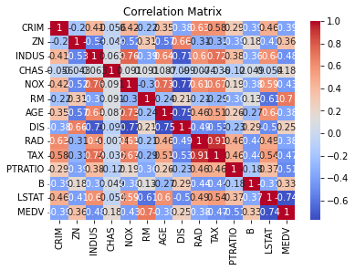

```python
import seaborn as sns
# calculate the correlation matrix
corr_matrix = boston.corr()

# plot the correlation matrix as a heatmap
sns.heatmap(corr_matrix, annot=True, cmap='coolwarm')
plt.title("Correlation Matrix")
plt.show()
```

Looking at the correlation matrix, we can see that the most strongly correlated feature with the target variable (MEDV) is the average number of rooms per dwelling (RM), with a correlation coefficient of 0.7. This indicates that as the number of rooms per dwelling increases, the median value of owner-occupied homes tends to increase as well. On the other hand, the percentage of lower status of the population (LSTAT) is strongly negatively correlated with MEDV, with a correlation coefficient of -0.74. This indicates that as the percentage of lower status of the population increases, the median value of owner-occupied homes tends to decrease.

#### plot a scatter plot between RM (the number of rooms per dwelling) and the percentage of lower status of the population (LSTAT) and meke MEDV(the median value of owner-occupied homes )as the target to see how the number of rooms per dwelling is related to the median value of owner-occupied homes.

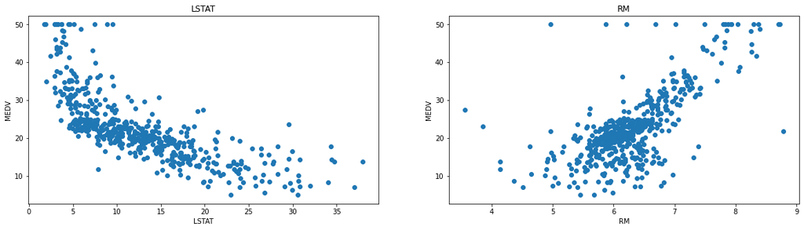

```python
plt.figure(figsize=(20, 5))

features = ['LSTAT', 'RM']
target = boston['MEDV']

for i, col in enumerate(features):
    plt.subplot(1, len(features) , i+1)
    x = boston[col]
    y = target
    plt.scatter(x, y, marker='o')
    plt.title(col)
    plt.xlabel(col)
    plt.ylabel('MEDV')
```

## Analysis

The scatter plot between the number of rooms per dwelling (RM) and the median value of owner-occupied homes (MEDV) indicates a positive linear relationship between these two variables. However, there are some outliers and a ceiling effect is observed in the data, as the maximum value of MEDV appears to be capped at 50.

On the other hand, the plot between the percentage of lower status of the population (LSTAT) and MEDV suggests a negative correlation between these variables. Although the relationship is not perfectly linear, the data suggests that the median value of owner-occupied homes tends to decrease as the percentage of lower status population increases.

## Reference

[1] Deep Learning with Python, 2017, by Chollet, Francois. Page 88- Page 108

[2]Guides of Keras, official site, https://keras.io/guides/

[3]Linear Regression on Boston Housing Dataset,Animesh Agarwal, https://towardsdatascience.com/linear-regression-on-boston-housing-dataset-f409b7e4a155

[4]Seaborn Heatmap – A comprehensive guide https://www.geeksforgeeks.org/seaborn-heatmap-a-comprehensive-guide/